# Economic Policies and Health Outcomes under Covid-19 A Microsimulation Analysis

Erol Taymaz  
Department of Economics, Middle East Technical University  
Ankara Turkey  
http://users.metu.edu.tr/etaymaz

18th International Schumpeter Conference / 08-10 July 2021

# Covid-19: Health or economy?

[figure not shown]

“President Donald Trump fixed his course on reopening the nation for business, acknowledging that the move would cause more illness and death from the pandemic but insisting it’s a cost he’s willing to pay to get the economy back on track.”

Source: [Bloomberg, 6 Mayıs 2020](https://www.bloomberg.com/news/articles/2020-05-06/trump-pivots-to-phase-two-risking-more-death-to-save-economy)

# Topics

- Is there a trade off between economic and health outcomes?

**Microsimulation model**

- Which policies are effective in reducing the spread of Covid-19?
- What are the costs of these policies in terms of foregone output (value added) and employment?
- Who are the most effected by these policies?
- What could the government do to reduce the social and economic cost of Covid-19?

# Covid-19 measures

- Stay-at-home rules (partial/general)
- Closing down businesses (restaurants, tourism, etc)
- Restricting certain (mass) activities (conferences, concerts, etc)
- Travel restrictions (local, national and international)
- Closing schools/on-line education
- Others
  - Testing and filiation
  - Masks, social distancing
  - Teleworking

# Economic effects of Covid-19 measures

**Short run**

- Decline in output and employment
  - Closing down businesses
  - Reducing (consumption) expenditures
    - Uncertainty and restrictions
    - Increasing unemployment
      - Income support
  - Decline in investment
  - Decline in foreign demand (declining exports)

# Economic effects of Covid-19 measures

**Long term**

- Depreciation of human capital
  - Health problems
  - Problems in education/access to on-line education
  - Increasing youth unemployment
- Declining investment
- Changes in consumer behavior
- Changes in the direction of technological change

# Health vs economics

**Economic effect:** Level x Duration **(-)** **Health effect:** Level x Duration **(+)**

- Economic effects
  - Decline in value added and employment
  - Policy stringency index
  - Google mobility index
    - Workplace mobility, retail and recreation mobility, etc
- Health effects
  - Covid-19 deaths
  - Additional deaths
  - Case numbers

# Turkey

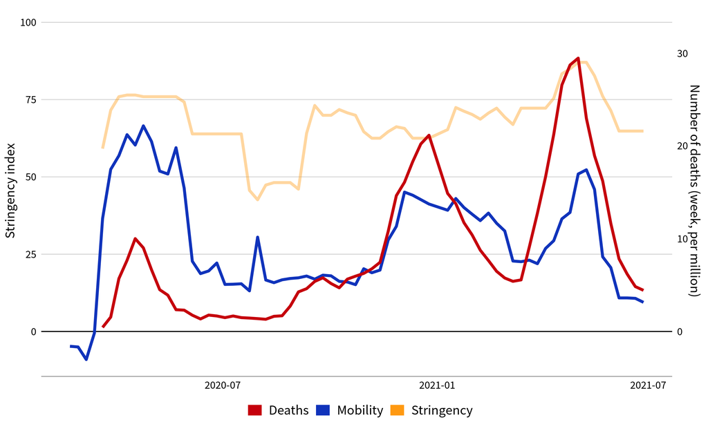

# Italy

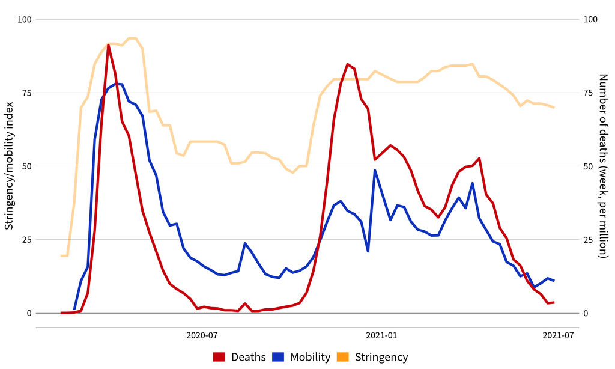

# United States

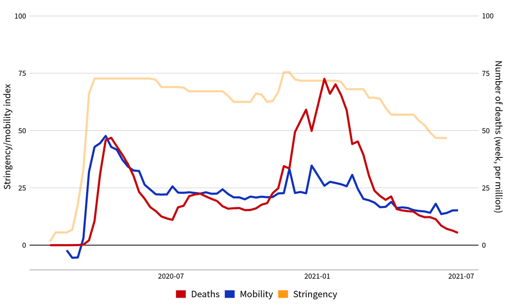

# Brazil

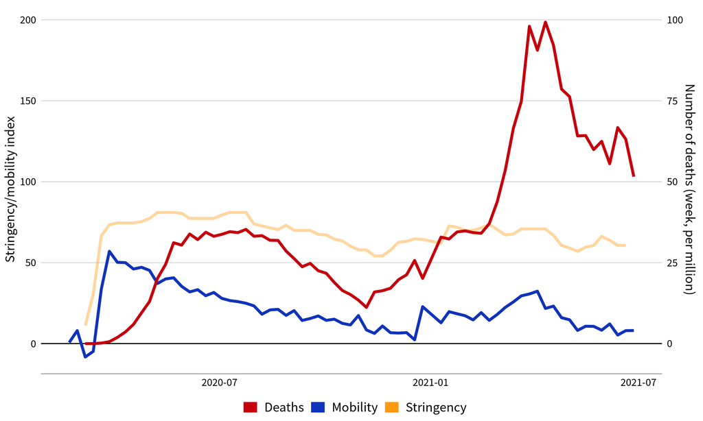

# New Zealand

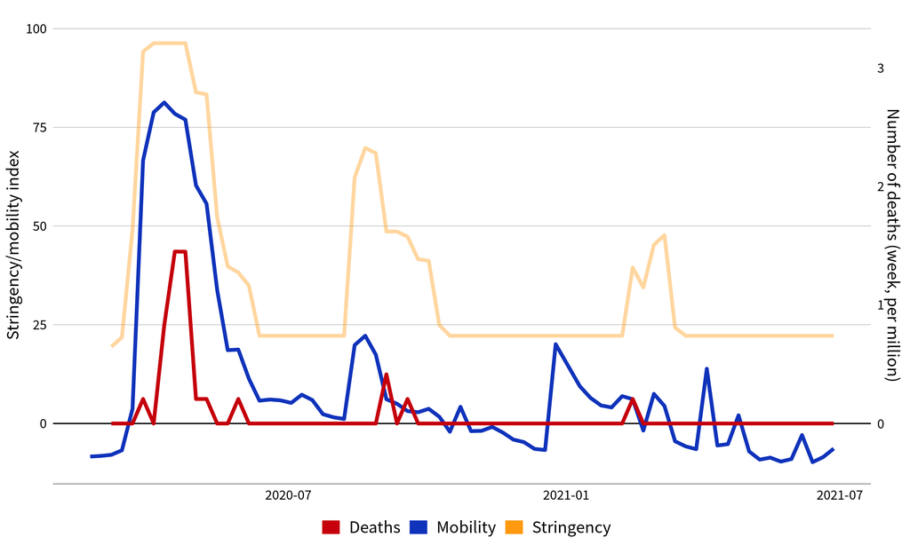

# Vietnam

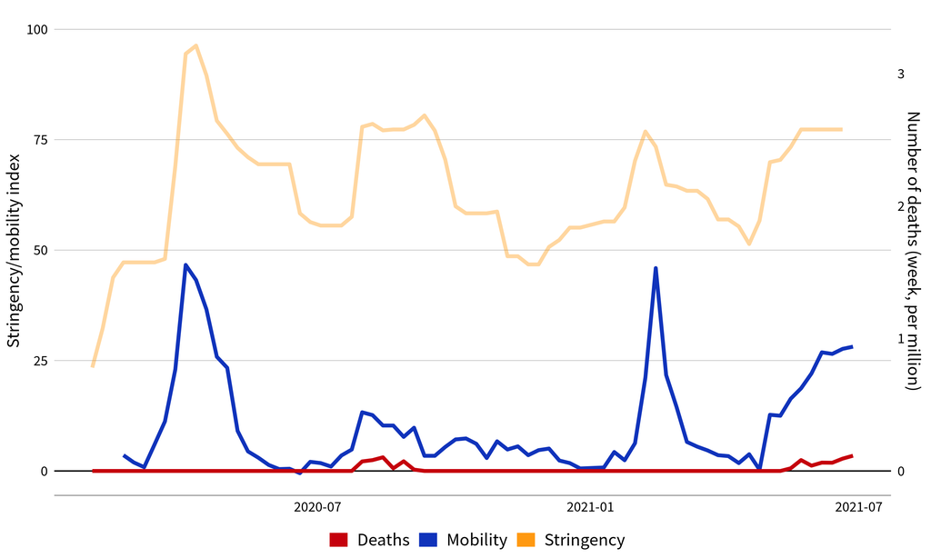

# Summary

| Country | Mobility | Number of deaths |
| --- | --- | --- |
| Italy | 2053 | 2109.9 |
| Turkey | 2017 | 589.7 |
| United States | 1581 | 1827.0 |
| Brazil | 1441 | 2437.3 |
| New Zealand | 634 | 5.4 |
| Vietnam | 727 | 0.8 |

# The microsimulation model

- Agents
  - About 500,000 individual representing whole population (about 80 million)
    - The number of unique individual in the model increases to 3-4 million during simulation
  - Household, age, gender, school, sector, occupation, formal/informal, working hours, region
  - 2017 Labor Survey Data
- Locations
  - Household: Household members
  - School: Students and the education sector employees in a given region (“region” is defined at NUTS 2-digit level).
  - Workplace: People employed in a given sector and region
  - Essential activities: All people living in a given region and those work in the “essential” sectors
  - Leisure activities: All people living in a given region and those work in the “leisure” sectors
  - Travel: All people

# Modules

- Disease progression module
- Infection module
- Measures/policies module
- Production and employment module

# Module 1: Disease progression module

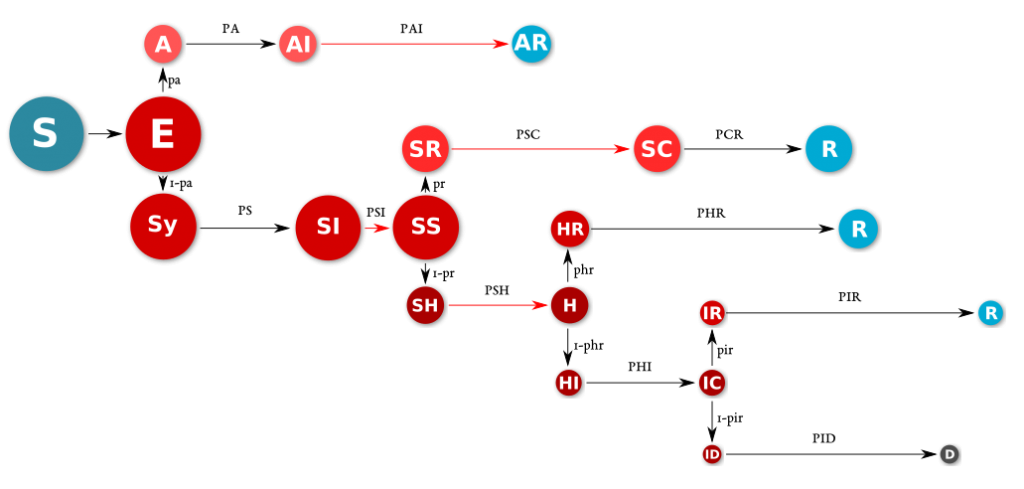

# Modul 2. Infection

- Individuals
  - pre-school, school, unemployed women, unemployed men, employed women, employed men
- Locations
  - home, school, workplace, essential activities, leisure activities, travel
- Each individual spends 16 hours per day in those locations
- The number of infected people in a given location in a day depends on
  - Time spent by susceptible people *times*
  - Time spent by infected people *over*
  - Time spent by all people (including recovered)
- In the case of essential and leisure activities, transmission probability depends the degree of contacts with customers [O*Net, “Deal With External Customers” data]
- For teleworking, Dingel and Neiman’s (2020) “work-at-home” data is used.

# Module 3. Measures/policies

- Closing schools
- Stay-home rules for 65+ years old
- Stay-home rules for 20- years old
- Travel restrictions (regional and national)
- Nation-wide lockdown
- Closing businesses
- Quarantine and isolation rules
- Social distancing

These measures/restrictions change the time use of individuals.

We take into account quarantine and isolation rules and social distancing measures as well.

# Module 4. Production and employment

- Economic effect of policies
  - Businesses closures -> decline in production and employment
    - Decline in demand for inputs (backward links)
    - Decline in households’ demand (income effect)
      - Income support by the government
    - Decline in investment and exports
- Use IO table to calculate these effects
  - For different categories of people (young/old, men/women, formal/informal, etc.)
  - For government finances (tax revenue - expenditures)

# Parameter values

- Publications
- Calibration
  - Daily data on cases, deaths, and ICU numbers

# What happened?

Number of deaths, real and simulated

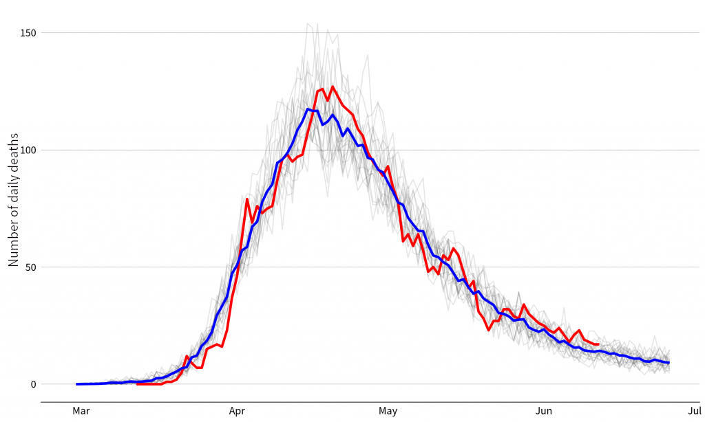

# What happened?

Number of cases, real and simulated

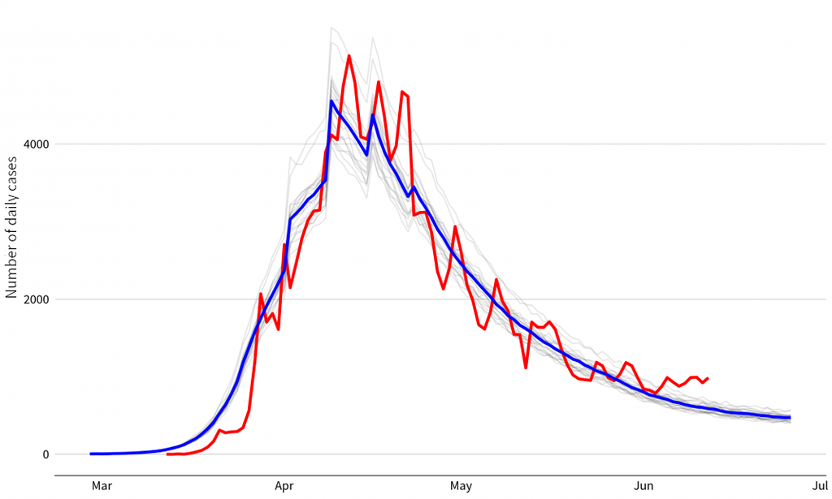

# Counterfactuals

Number of cases, real and no restrictions

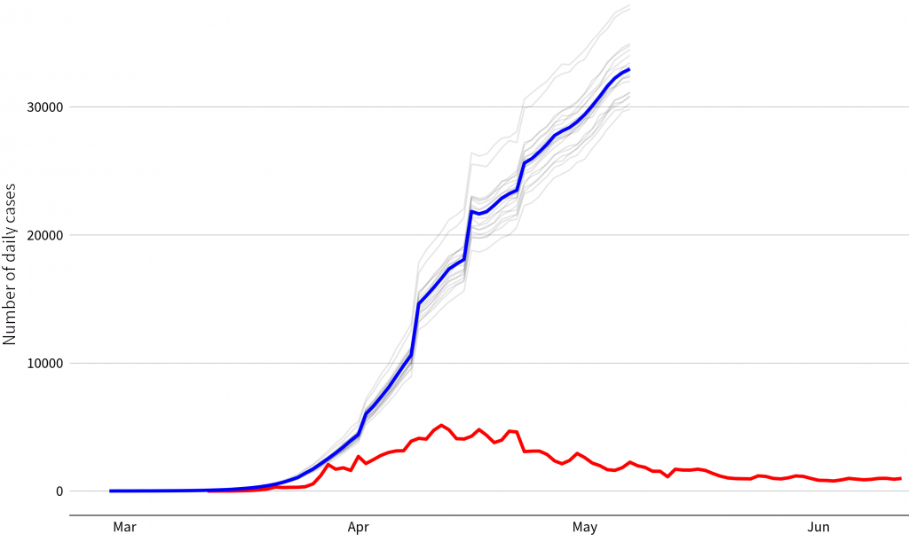

# Counterfactuals

Number of cases, real and early implementation

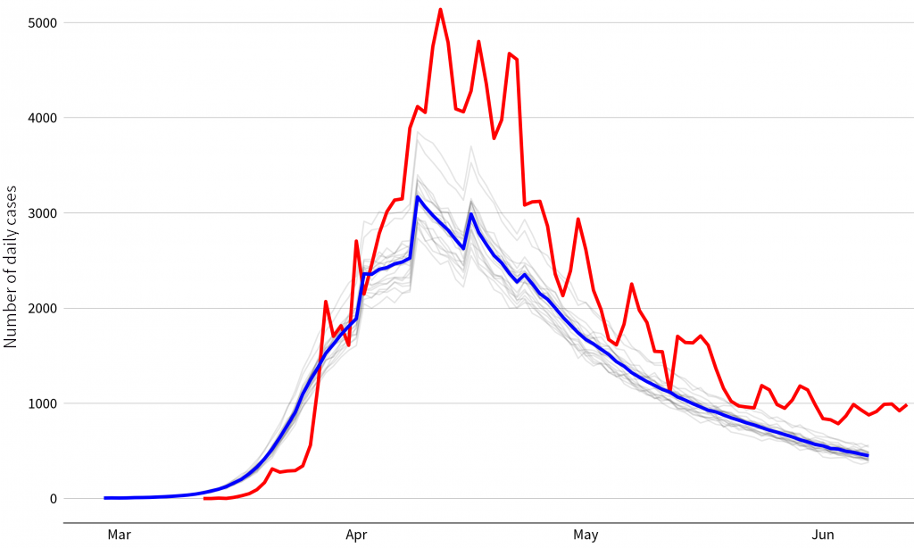

# Counterfactuals

Number of cases, real and full lockdown

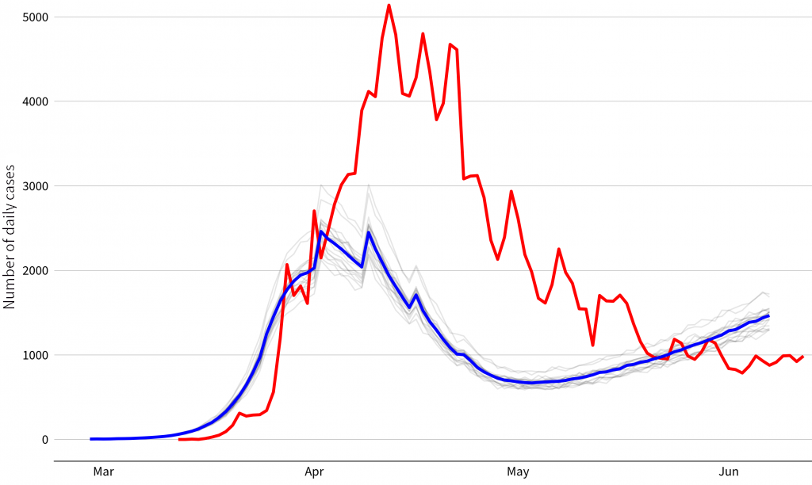

# Counterfactuals?

Policy responses and outcomes, March 18-May 31, 2020

|  | Realized | Simulated | Full lockdown | Early imp. |
| --- | --- | --- | --- | --- |
| Total cases | 169218 | 173439 | 100895 | 124044 |
| Total deaths | 4669 | 4730 | 2763 | 3462 |
| Employment loss |  | 3642 | 3639 | 3578 |
| Wage loss |  | 317 | 311 | 312 |

# Results

- There is no trade off between economy and health (in the case of Covid-19)
- Microsimulation is a useful tool
  - Which measures are effective?
  - What are the costs of measures?
  - Who are the most effected?
  - What could the government do?

*Many thanks…*